## Professor Sayamindu Dasgupta

## INLS 490.278

## 27 April 2020

# Wikipedia & Covid 19

## Framing & Questions

### Framing

#### Why Wikipedia?

Wikipedia is a free enyclopedia that allows anyone to edit and search it. The accessability of Wikipedia to the public is key to its popularity.

#### Why Covid-19?

The world is grappeling with a global pandemic in the form of COVID-19. As an information scientist, I have a responsibility to do what little I can to help.

#### How do the two interact?

It’s important for researchers to understand the information ecosystem that is present on Wikipedia and how users and editors interact with Wikipedia articles during times like these. Understanding this will allow researchers to better understand the information seeking behaviors of the population at large in times of crisis. This can aid in tailoring public health messages to more effectively reach their audience(s).

### Questions

#### I started with two original research questions and hypotheses:

Do the Wikipedia Articles for respiratory outbreaks have a similar page view trend to Covid-19’s?

- My hypothesis was they would

Do the editors of those articles overlap?

- My hypothesis was they would.

#### Over the course of this project, I came up with or had suggested to me some other questions:

Are there similar trends across different language Wikipedia articles?

- My hypothesis was there likely would be.

Does the inclusion of redirects change the trends in page views?

- My hypothsis was they likely would not.

## Prior Work

There’s a body of prior work done with regards to Wikipedia editing behavior. It includes research on identifying who is doing the editing (bots vs. anonymous users vs. identified users) (Stiener 2014). It also includes work looking at how news impacts Wikipedia views and edits (Geiß et al. 2016). Finally, it includes research looking at the use of Wikpieda for the automatic detection of events (Tran et Al. 2014).

There’s also quite a bit of research on page views. This includes some research looking at the French Language Wikipedia page views and the usability of those as a metric in public health monitoring (Pascal et al. 2017). This also includes research using Wikipedia Page views as an alternative to search logs as a way of indicating public interest in a subject (Yoshida et al. 2015). It additionally includes research indicating the use of Wikipedia page views as showing what internet users are interested in finding more information about as opposed to the surface level of a google search (Kampf et al. 2015). As well as research that among other things noted Wikipedia Page views and edit activity as a measure of public interest (Mahroum et al. 2018). Finally, this includes research showing Wikipedia as a leading source of health information (Laurent & Vickers 2009).

Finally, Hill & Shaw in covered the importance of considering the redirect when doing any sort of Wikipedia research. In particular, they noted the fact that redirect pages work as a hidden layer of Wikipedia.Thus, any research on pageviews or editing behavior should as they put it "consider the redirect" and the role it plays (Hill & Shaw 2014).

## Data Collection

I focused on the datetime and comment columns in the edit data. I used the comment text and a regular expression to find the various names the articles went through no matter the language of the page. I used the edit dates to make a dictionary of the daily edits so track the edits over time.

When it came to the pageviews, I focused on the datetime and the pageviews and I put that into a dictionary. I repeated this for each language and for each article. I set the level of granularity to daily as I figured it was more important to see a day by day level of views than any other.

In the language of wikipedia, I didn't distinguish between agents. To put it plain english, I made the decision to treat all means of access as being equal; I didn't make a distinction between mobile and non-mobile users,and bots. I made that decision because I feel it's equally indicative of a level of interest to visit a site yourself as it is to have a bot visit it.

The articles I focused on were the articles for the Covid-19 Pandemic, the article for Covid-19 ad a disease, the article for SARS, the article for MERS, and the article for the H1N1 pandemic. The names varied between languages but I am confident they were more or less equivalent in terms of what they covered.

## Method

My methods for analysis was fairly simplistic. I made a large number of graphs and relied on visual comparison when it came to pageview trends.

When it came to similarity of editors I relied on Jaccard Similarity to be my guide. Jaccard Similarity is a measure of similarity derived from the number of items in the intersection of two sets divided by the number of items in the union of two sets.

## Results

### Pageviews

#### Covid-19 Pandemic vs. Coronvirus Disease 2019 (English)

Looking at the graph showing the pageviews of the Panedmic page vs the Disease page in English, you can see there's a degree of similarity in how the pageview trends go over time.

[figure not shown]

#### Covid-19 Pandemic Vs SARS vs. MERS vs. H1N1 Pandemic (English)

Comparing the pageview trends of the Covid-19 Pandemic Page to that of the SARS, MERS, and H1N1 Pandemic pages, we can see they don't appear to be closely related in terms of their view trends for the most part. It's worth noting the articles we're comparing to the Covid Pandemic article appear to share spikes in pageview around the same times as the Pandemic article. However, they don't entirely line up so I'm not confident saying the results here were that the trends in pageviews match up.

[figure not shown]

#### English Vs. Italian Pageviews

Comparing the English and Italian language page views for the pandemic and disease articles, we can see that they follow different trends which makes sense. But in both cases, they mostly follow the same pattern within the language. That is to say, the pageviews for the pandemic and disease pages track together in terms of when they have peaks and valleys.

[figure not shown]

#### English Vs. French

Comparing the English and French language page views for the pandemic and disease articles, we can see they follow different trends just like comparing Italian and English. This makes sense again. And again, the pageviews within the language follow the same pattern and track together in when they have their zenith and nadir.

[figure not shown]

### Similarity

Jaccard Similarity is a measure of similarity which is computed by taking the number of items in an intersection of two sets divided by the number of items in the union of two sets. Jaccard Similarity scores range from 0 to 1 with 0 being perfectly dissimilar and 1 being perfectly simmilar.

I calculated the Jaccard Similarity for the top 10 and top 100 editors for the english Wikipedia articles I looked at. In each instance I compared the similarity to that of the Covid-19 pandemic page.

Looking at the articles compared here, You can clearly see they aren't that similar. Every article pair compared except for the Covid Disease and Pandemic pages are at most .05. The similarity isn't that much above what I'd call baseline.

[output not shown]

For the purpose of comparison, I calculated Jaccard Similarities for a few other articles. The articles in question were Paisley Abbey, The Assassination of Abraham Lincoln, and the Umbrella Movement. As you can see, the editors seem to be very disimilar at the level of the top ten editors and only very slightly similar at the level of the top 100 editors.This would seem to make the scores for the articles above to be more similar than the baseline but that's not saying much.

| Articles Compared | Jaccard Similarity |
| --- | --- |
| Paisley Abbey & Assassination of Abraham Lincoln (100) | 0.0101 |
| Paisley Abbey & Umbrella Movement (100) | 0.0256 |
| Umbrella Movement & Assassination of Abraham Lincoln (100) | 0.005 |
| Paisley Abbey & Assassination of Abraham Lincoln (10) | 0.0 |
| Paisley Abbey & Umbrella Movement (10) | 0.0 |
| Umbrella Movement & Assassination of Abraham Lincoln (10) | 0.0 |

Overalll, it's difficult to say that the articles are slightly more similar in terms of editors than the baseline with the exception of the Covid Disease and Pandemic pages.

## Limitations

There were limitations to my work. I made certain assumptions that impact the ability to make complete statements.

I made the assumption that the top editors are stable over time. That is to say, the editors who were editing an article a year ago are likely to be the same ones today. It assumes that there is relatively low "churn" in the editors of articles.

Finally, I made the assumption that it was important to track all agents in the same fashion. That is to say to not distinguish between mobile users, bots, and desktop users. I feel that is a valid decision given I'm treating pageviews as a measure of interest but it still needs to be acknowledged that an assumption was made.

While I attempted to include the data from the French and Italian language wikipedias, my knowledge of those languages is extremely limited. Thus, I am unable to say with any degree of certainty that I found exactly was I was looking for. That means that any results I acheived are probably suspect. Further, I restricted my comparison to only the Pandemic and Disease pages for each langueg. This further limits my ability to draw broader conclusions.

I also failed to include redirects in my research. As found by what their names, redirects are important when it comes to wikipedia research so failing to include them means my research may not be terribly rigorous.

One final isue I feel may limit me is the lack of uniformity in terms of when articles started. There isn't a one to one timescale between some of the articles in any of the languages. For example, the pandemic and disaeas pages didn't tend to be created the same time. And these articles weren't created at the same time in other languages either. This complicates analysis as we cannot make a one to one comparison between the two of them.

## Future Research

In future research, it would be good to expand the comparison across languages to include more languages and more articles. It would also be good to expand the editor comparison across more languages rather than just restricting it to English.

Looking at the "churn" of editors in a Wikipedia article or in Wikipedia articles in general would be very interesting. It could give an idea as to how consistent the editors are with Wikipedia articles.

It would also be good to look at the edit frequency of old versus new Wikipedia Articles. That could prove very illuminating on the editing behavior of Wikipedians.

## Works Cited

Vilain, Pascal, et al. “Wikipedia: a Tool to Monitor Seasonal Diseases Trends?” Online Journal of Public Health Informatics, vol. 9, no. 1, 2017, doi:10.5210/ojphi.v9i1.7630.

Yoshida, Mitsuo, et al. “Wikipedia Page View Reflects Web Search Trend.” Proceedings of the ACM Web Science Conference on ZZZ - WebSci '15, June 2015, doi:10.1145/2786451.2786495.

Kämpf, Mirko, et al. “The Detection of Emerging Trends Using Wikipedia Traffic Data and Context Networks.” Plos One, vol. 10, no. 12, 31 Dec. 2015, doi:10.1371/journal.pone.0141892.

Laurent, M. R., and T. J. Vickers. “Seeking Health Information Online: Does Wikipedia Matter?” Journal of the American Medical Informatics Association, vol. 16, no. 4, 2009, pp. 471–479., doi:10.1197/jamia.m3059.

Mahroum, Naim, et al. “Public Reaction to Chikungunya Outbreaks in Italy—Insights from an Extensive Novel Data Streams-Based Structural Equation Modeling Analysis.” Plos One, vol. 13, no. 5, 24 May 2018, doi:10.1371/journal.pone.0197337.

Mahroum, Naim, et al. “Public Reaction to Chikungunya Outbreaks in Italy—Insights from an Extensive Novel Data Streams-Based Structural Equation Modeling Analysis.” Plos One, vol. 13, no. 5, 24 May 2018, doi:10.1371/journal.pone.0197337.

Geiß, Stefan, et al. “The Interplay between Media-for-Monitoring and Media-for-Searching: How News Media Trigger Searches and Edits in Wikipedia.” New Media & Society, vol. 18, no. 11, 2016, pp. 2740–2759., doi:10.1177/1461444815600281.

Steiner, Thomas. “Bots vs. Wikipedians, Anons vs. Logged-Ins (Redux).” Proceedings of The International Symposium on Open Collaboration - OpenSym '14, Aug. 2014, doi:10.1145/2641580.2641613.

Tran, Tuan, et al. “WikipEvent: Leveraging Wikipedia Edit History for Event Detection.” Web Information Systems Engineering – WISE 2014 Lecture Notes in Computer Science, Oct. 2014, pp. 90–108., doi:10.1007/978-3-319-11746-1_7.

Hill, Benjamin Mako, and Aaron Shaw. “Consider the Redirect.” Proceedings of The International Symposium on Open Collaboration - OpenSym '14, Aug. 2014, doi:10.1145/2641580.2641616.

## Code

```python
# importing all the libraries used
import requests
import pprint
import pandas as pd
import matplotlib.pyplot as plt
import time
import matplotlib.ticker as ticker
import re

# leads to higher quality image...
%config InlineBackend.figure_format = 'retina'
```

### English Pageviews and Graphs

#### Getting the data

```python
#setting the date range
date = "/20200105/20200419"
# this date because the Covid 19 Disease page didn't exist before then...which makes analysis difficult
```

```python
# getting the pageviews for the covid-19 pandemic page(s)
covid_pan_list = ["2019-2020 China pneumonia outbreak",
                   "2019–20 China pneumonia outbreak",
                   "2019-20 China pneumonia outbreak",
                   "2019-20 outbreak of novel coronavirus (2019-nCoV) in Wuhan, China",
                    "2019-20 outbreak of novel coronavirus (2019-nCoV)",
                   "2019–20 outbreak of novel coronavirus (2019-nCoV)",
                   "2019–20 outbreak of novel coronavirus 2019-nCoV",
                   "2019–20 Wuhan coronavirus outbreak",
                   "2019–20 coronavirus outbreak",
                   "2019–20 coronavirus pandemic"]

covid_pan_dict = {}

for name in covid_pan_list:

    wp_call = requests.get("https://wikimedia.org/api/rest_v1/metrics/pageviews/per-article/en.wikipedia.org/all-access/all-agents/"+name+"/daily"+date)


    response = wp_call.json()

    page_count = 0
    #print(response)

    for entry in response:

        for item in response[entry]:

            #print(item["timestamp"],item["views"])

            timestamp = item["timestamp"][4:6]+"/"+item["timestamp"][6:8]+"/"+item["timestamp"][0:4]

            if timestamp in covid_pan_dict:
                covid_pan_dict[timestamp] += item["views"]

            else:
                covid_pan_dict.setdefault(timestamp,item["views"])

    time.sleep(1)
```

```python
covid_disease_page_name_list = ["2019-nCoV Acute Respiratory Syndrome","2019-nCoV Acute Respiratory Disease",
                                "2019-nCoV acute respiratory disease","COVID-19",
                                "Coronavirus disease 2019",
                                "Coronavirus Hell No", "Nazi Coronavirus"]
```

```python
# getting the pageviews for the covid-19 disease page(s)
covid_dis_dict = {}

for name in covid_disease_page_name_list:


    wp_call = requests.get("https://wikimedia.org/api/rest_v1/metrics/pageviews/per-article/en.wikipedia.org/all-access/all-agents/"+name+"/daily"+date)


    response = wp_call.json()

    page_count = 0
    #print(response)

    for entry in response:

        for item in response[entry]:

            #print(item["timestamp"],item["views"])

            timestamp = item["timestamp"][4:6]+"/"+item["timestamp"][6:8]+"/"+item["timestamp"][0:4]


            if timestamp in covid_dis_dict:
                covid_dis_dict[timestamp] += item["views"]

            else:
                covid_dis_dict.setdefault(timestamp,item["views"])

    time.sleep(1)
```

```python
# getting the pageviews for the mers page
mers_dict = {}

wp_call = requests.get("https://wikimedia.org/api/rest_v1/metrics/pageviews/per-article/en.wikipedia.org/all-access/all-agents/Middle_East_respiratory_syndrome/daily"+date)


response = wp_call.json()

page_count = 0
#print(response)

for entry in response:

    for item in response[entry]:

        #print(item["timestamp"],item["views"])

        timestamp = item["timestamp"][4:6]+"/"+item["timestamp"][6:8]+"/"+item["timestamp"][0:4]
        #print(timestamp)

        mers_dict.setdefault(timestamp,item["views"])
```

```python
# getting the page views for the sars page
sars_dict = {}


wp_call = requests.get("https://wikimedia.org/api/rest_v1/metrics/pageviews/per-article/en.wikipedia.org/all-access/all-agents/Severe_acute_respiratory_syndrome/daily"+date)


response = wp_call.json()

page_count = 0
#print(response)

for entry in response:
    for item in response[entry]:

        timestamp = item["timestamp"][4:6]+"/"+item["timestamp"][6:8]+"/"+item["timestamp"][0:4]

        sars_dict.setdefault(timestamp,item["views"])
```

```python
# getting the page views for the h1n1 page(s)
h1n1_name_list = ["2009 flu pandemic", "2009 swine flu pandemic"]

h1n1_dict = {}

for name in h1n1_name_list:


    wp_call = requests.get("https://wikimedia.org/api/rest_v1/metrics/pageviews/per-article/en.wikipedia.org/all-access/all-agents/"+name+"/daily"+date)


    response = wp_call.json()

    page_count = 0
    #print(response)

    for entry in response:

        for item in response[entry]:

            #print(item["timestamp"],item["views"])

            timestamp = item["timestamp"][4:6]+"/"+item["timestamp"][6:8]+"/"+item["timestamp"][0:4]


            if timestamp in h1n1_dict:
                h1n1_dict[timestamp] += item["views"]

            else:
                h1n1_dict.setdefault(timestamp,item["views"])

    time.sleep(1)
```

#### Making the Graphs

```python
#graphing the data - covid pandemic vs. covid disease pages

covid_dis_list = sorted(covid_dis_dict.items())
covid_pan_list = sorted(covid_pan_dict.items())

x1,y1 = zip(*covid_dis_list)
x2, y2 = zip(*covid_pan_list)

# main plot to compare
fig = plt.figure()
graph = fig.gca()
graph.plot(x2,y2, "#0047AB", label="Covid-19 Pandemic")
graph.plot(x1,y1, "#259FED", label = "Coronavirus disease 2019")
graph.tick_params(axis ='x', rotation = -60)
plt.legend(loc="upper left")
plt.ylabel("Pageviews")
plt.title("Pandemic vs. Disease pageviews")
graph.xaxis.set_major_locator(ticker.AutoLocator())
graph.xaxis.set_minor_locator(ticker.AutoMinorLocator())

plt.savefig("dis_v_pan_eng_graph.svg", bbox_inches="tight", pad_inches=.25)

plt.show
```

```python
# comparing the Pandemic page with the SARS, MERS, & H1N1 pages.
sars_list = sorted(sars_dict.items())
mers_list = sorted(mers_dict.items())
h1n1_list = sorted(h1n1_dict.items())

x3,y3 = zip(*sars_list)
x4, y4 = zip(*mers_list)
x5, y5 = zip(*h1n1_list)


figures, axes = plt.subplots(nrows=2,ncols=2,sharey=False, sharex=True)
plt.subplots_adjust(left=None, bottom=None, right=1, top=None, wspace=.3, hspace=.3)

for axis in axes.flat:
    axis.tick_params(axis ='x', rotation = -60)
    axis.xaxis.set_major_locator(ticker.AutoLocator())
    axis.xaxis.set_minor_locator(ticker.AutoMinorLocator())



axes[0,0].plot(x2,y2, color = "#0047AB")
axes[0,0].set_title("Covid-19 Pandemic")



axes[0,1].plot(x3,y3,color="#1277DD")
axes[0,1].set_title("SARS")

axes[1,0].plot(x4,y4,color="#259FED")
axes[1,0].set_title("MERS")

axes[1,1].plot(x5,y5,color="#01BFFF")
axes[1,1].set_title("H1N1")


plt.savefig("4_compared_eng_graph.svg", bbox_inches="tight", pad_inches=.25)

plt.show()
```

### Italian Pageviews & Graphs

```python
# italian pages for Covid-19 Disease & the pandemic respectively.
"https://it.wikipedia.org/wiki/COVID-19"
"https://it.wikipedia.org/wiki/Pandemia_di_COVID-19_del_2019-2020"
```

```
'https://it.wikipedia.org/wiki/Pandemia_di_COVID-19_del_2019-2020'
```

```python
italian_pandemic_name_list = ['Epidemia di COVID-19 del 2019-2020',
 'Pandemia di COVID-19 del 2019-2020',
 'Epidemia di SARS-CoV-2 del 2019-2020',
 'Epidemia di 2019-nCoV del 2019-2020',
 'Epidemia da 2019-nCoV del 2019-2020',
 'Epidemia di polmonite da 2019-nCoV del 2019-2020',
 'Epidemia di pomonite da 2019-nCoV del 2019-2020',
 'Epidemia di coronavirus 2019-nCoV']
```

```python
# retrieving the page views at a daily level for the Italian article.
# first daily views recorded was on 2/11/2020 - peak views is 36k
it_covid_dis_dict = {}


wp_call = requests.get("https://wikimedia.org/api/rest_v1/metrics/pageviews/per-article/it.wikipedia.org/all-access/all-agents/COVID-19/daily"+date)


response = wp_call.json()

page_count = 0
#print(response)

for entry in response:
    for item in response[entry]:

        timestamp = item["timestamp"][4:6]+"/"+item["timestamp"][6:8]+"/"+item["timestamp"][0:4]

        it_covid_dis_dict.setdefault(timestamp,item["views"])
```

```python
# retrieving the page views at a daily level for the Italian article for Covid-19 pandemic
it_covid_pan_dict = {}

for name in italian_pandemic_name_list:



    wp_call = requests.get("https://wikimedia.org/api/rest_v1/metrics/pageviews/per-article/it.wikipedia.org/all-access/all-agents/"+name+"/daily"+date)


    response = wp_call.json()

    page_count = 0
    #print(response)

    for entry in response:
        for item in response[entry]:

            timestamp = item["timestamp"][4:6]+"/"+item["timestamp"][6:8]+"/"+item["timestamp"][0:4]

            if timestamp not in it_covid_pan_dict:
                it_covid_pan_dict.setdefault(timestamp,item["views"])
            else:
                it_covid_pan_dict[timestamp] += item["views"]

    time.sleep(1)
```

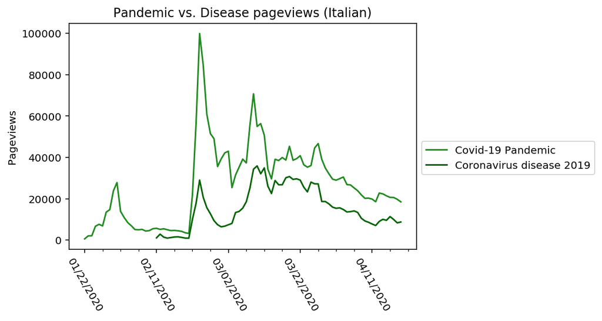

```python
it_covid_dis_list = sorted(it_covid_dis_dict.items())
it_covid_pan_list = sorted(it_covid_pan_dict.items())

x1,y1 = zip(*it_covid_dis_list)
x2, y2 = zip(*it_covid_pan_list)

# main plot to compare
fig = plt.figure()
graph = fig.gca()
graph.plot(x2,y2, "#228B22", label="Covid-19 Pandemic")
graph.plot(x1,y1, "#006400", label = "Coronavirus disease 2019")
graph.tick_params(axis ='x', rotation = -60)
plt.legend(loc='upper left', bbox_to_anchor=(1, 0.5))
plt.ylabel("Pageviews")
plt.title("Pandemic vs. Disease pageviews (Italian)")
graph.xaxis.set_major_locator(ticker.AutoLocator())
graph.xaxis.set_minor_locator(ticker.AutoMinorLocator())

plt.savefig("dis_v_pan_it_graph.svg", bbox_inches="tight", pad_inches=.25)
plt.show()
```

### French Pageviews & Graphs

```python
# french pages for Covid-19 the pandemic & Disease  respectively.
"https://fr.wikipedia.org/wiki/Pandémie_de_Covid-19"
"https://fr.wikipedia.org/wiki/Maladie_à_coronavirus_2019"
```

```
'https://fr.wikipedia.org/wiki/Maladie_à_coronavirus_2019'
```

```python
french_pan_list = ['Pandémie de maladie à coronavirus de 2019-2020', 'Pandémie de Covid-19',
                   'Pandémie de Covid-19 de 2019-2020', 'Pandémie de maladie à coronavirus de 2019-2020)',
                   'Pandémie de covid-19', 'Pandémie de la maladie à coronavirus de 2019-2020',
                   'Pandémie de la maladie du coronavirus de 2019-2020', 'Pandémie de COVID-19 de 2019-2020',
                   'Pandémie de coronavirus de 2019-2020', 'Épidémie de maladie à coronavirus de 2019-2020',
                   'Épidémie de maladie à COVID-19 de 2019-2020', 'Épidémie de coronavirus de 2019-2020',
                   'Épidémie du coronavirus de 2019-2020', 'Epidémnie du coronavirus de 2019-2020']
```

```python
# retrieving the page views at a daily level for the French article for Covid-19 pandemic
fr_covid_pan_dict = {}

for name in french_pan_list:


    wp_call = requests.get("https://wikimedia.org/api/rest_v1/metrics/pageviews/per-article/fr.wikipedia.org/all-access/all-agents/"+name+"/daily"+date)


    response = wp_call.json()

    page_count = 0
    #print(response)

    for entry in response:
        for item in response[entry]:

            timestamp = item["timestamp"][4:6]+"/"+item["timestamp"][6:8]+"/"+item["timestamp"][0:4]

            if timestamp not in fr_covid_pan_dict:
                fr_covid_pan_dict.setdefault(timestamp,item["views"])
            else:
                fr_covid_pan_dict[timestamp] += item["views"]
```

```python
french_disease_list = ['Maladie à coronavirus de 2019', 'Maladie à coronavirus 2019', 'COVID-19',
                            'Pneumonie de Wuhan']
```

```python
# retrieving the page views at a daily level for the French article for Covid-19 disease

fr_covid_dis_dict = {}

for name in french_disease_list:

    wp_call = requests.get("https://wikimedia.org/api/rest_v1/metrics/pageviews/per-article/fr.wikipedia.org/all-access/all-agents/"+name+"/daily"+date)


    response = wp_call.json()

    page_count = 0
    #print(response)

    for entry in response:
        for item in response[entry]:

            timestamp = item["timestamp"][4:6]+"/"+item["timestamp"][6:8]+"/"+item["timestamp"][0:4]

            if timestamp not in fr_covid_dis_dict:
                fr_covid_dis_dict.setdefault(timestamp,item["views"])
            else:
                fr_covid_dis_dict[timestamp] += item["views"]
```

[figure not shown]

```python
fr_covid_dis_list = sorted(fr_covid_dis_dict.items())
fr_covid_pan_list = sorted(fr_covid_pan_dict.items())

x1,y1 = zip(*fr_covid_dis_list)
x2, y2 = zip(*fr_covid_pan_list)

# main plot to compare
fig = plt.figure()
graph = fig.gca()
graph.plot(x1,y1, "#FF0000", label="Covid-19 Pandemic")
graph.plot(x2,y2, "#8B0000", label = "Coronavirus disease 2019")
graph.tick_params(axis ='x', rotation = -60)
plt.legend(loc='upper left', bbox_to_anchor=(1, 0.5))
plt.ylabel("Pageviews")
plt.title("Pandemic vs. Disease pageviews (French)")
graph.xaxis.set_major_locator(ticker.AutoLocator())
graph.xaxis.set_minor_locator(ticker.AutoMinorLocator())

plt.savefig("dis_v_pan_fr_graph.svg", bbox_inches="tight", pad_inches=.25)
plt.show()
```

### Jaccard Similarity

#### The 5 Main Articles

```python
import requests
import matplotlib.pyplot as plt
import pprint
import pandas as pd
from operator import itemgetter
import time
```

```python
# defining a function to return the Jaccard Similarity of sets passed to it.
def jac_sim(set1, set2):

    #print(set1.intersection(set2))
    #print(set1.union(set2))

    jaccard_similiarity = float(len(set1.intersection(set2)))/float(len(set1.union(set2)))



    return jaccard_similiarity
```

```python
topic_list = ["2009_flu_pandemic","Middle_East_respiratory_syndrome",
                  "Severe_acute_respiratory_syndrome","2019–20_coronavirus_pandemic", "Coronavirus disease 2019"]
```

Retrieving the edit history of the articles

```python
# retrieving the Pandemic edit history
parameters = {'action' : 'query',
              'prop' : 'revisions',
              'titles' : '2019–20_coronavirus_pandemic',
              'rvlimit' : 100,
              'rvprop' : "timestamp|user",
              'format' : 'json',
              'continue' : ''}

covid_users = {}

while True:
    wp_call = requests.get('https://en.wikipedia.org/w/api.php', params=parameters)
    response = wp_call.json()


    for page_id in response["query"]["pages"]:
        page_title = response["query"]["pages"][page_id]["title"]
        revisions = response["query"]["pages"][page_id]["revisions"]

        for rev in revisions:
            timestamp =  rev['timestamp']
            reviser = rev["user"]
            parsed_timestamp = timestamp.split('T')
            date = parsed_timestamp[0]

            covid_users.setdefault(reviser, 0)
            if reviser in covid_users:
                covid_users[reviser] += 1




    if 'continue' in response:
        parameters.update(response['continue']) # This updates the parameter so that we get the next set of data
    else:
        break
```

```python
# creating a pandas dataframe from the dictionary
covid_df = pd.DataFrame.from_dict(covid_users, orient="index", columns=["count"])
covid_pan_df_top_100 = covid_df.sort_values(by = "count", ascending = False).head(100)
covid_pan_df_top_100.index.names = ['user']
```

```python
# retrieving the disease edit history

parameters = {'action' : 'query',
              'prop' : 'revisions',
              'titles' : 'Coronavirus disease 2019',
              'rvlimit' : 100,
              'rvprop' : "timestamp|user",
              'format' : 'json',
              'continue' : ''}

covid_dis_users = {}

while True:
    wp_call = requests.get('https://en.wikipedia.org/w/api.php', params=parameters)
    response = wp_call.json()


    for page_id in response["query"]["pages"]:
        page_title = response["query"]["pages"][page_id]["title"]
        revisions = response["query"]["pages"][page_id]["revisions"]

        for rev in revisions:
            timestamp =  rev['timestamp']
            reviser = rev["user"]
            parsed_timestamp = timestamp.split('T')
            date = parsed_timestamp[0]

            covid_dis_users.setdefault(reviser, 0)
            if reviser in covid_dis_users:
                covid_dis_users[reviser] += 1




    if 'continue' in response:
        parameters.update(response['continue']) # This updates the parameter so that we get the next set of data
    else:
        break
```

```python
# creating a pandas dataframe from the dictionary
covid_dis_df = pd.DataFrame.from_dict(covid_dis_users, orient="index", columns=["count"])
covid_dis_df_top_100 = covid_dis_df.sort_values(by = "count", ascending = False).head(100)
covid_dis_df_top_100.index.names = ['user']
```

```python
# retrieving the MERS edit history

parameters = {'action' : 'query',
              'prop' : 'revisions',
              'titles' : 'Middle_East_respiratory_syndrome',
              'rvlimit' : 15,
              'rvprop' : "timestamp|user",
              'format' : 'json',
              'continue' : ''}

mers_users = {}

while True:
    wp_call = requests.get('https://en.wikipedia.org/w/api.php', params=parameters)
    response = wp_call.json()


    for page_id in response["query"]["pages"]:
        page_title = response["query"]["pages"][page_id]["title"]
        revisions = response["query"]["pages"][page_id]["revisions"]

        for rev in revisions:
            timestamp =  rev['timestamp']
            reviser = rev["user"]
            parsed_timestamp = timestamp.split('T')
            date = parsed_timestamp[0]

            mers_users.setdefault(reviser, 0)
            if reviser in mers_users:
                mers_users[reviser] += 1




    if 'continue' in response:
        parameters.update(response['continue']) # This updates the parameter so that we get the next set of data
    else:
        break
```

```python
# creating a pandas dataframe of the top 100 editors from the dictionary of the editors
mers_df = pd.DataFrame.from_dict(mers_users, orient="index", columns=["count"])
mers_top_100 = mers_df.sort_values(by = "count", ascending = False).head(100)
mers_top_100.index.names = ['user']
```

```python
# retrieving the SARS edit history

parameters = {'action' : 'query',
              'prop' : 'revisions',
              'titles' : "Severe_acute_respiratory_syndrome",
              'rvlimit' : 100,
              'rvprop' : "timestamp|user|comment",
              'format' : 'json',
              'continue' : ''}

sars_users = {}

while True:
    wp_call = requests.get('https://en.wikipedia.org/w/api.php', params=parameters)
    response = wp_call.json()


    for page_id in response["query"]["pages"]:

        page_title = response["query"]["pages"][page_id]["title"]
        revisions = response["query"]["pages"][page_id]["revisions"]

        for rev in revisions:

            timestamp = rev["timestamp"]
            user = rev["user"]

            if user not in sars_users:
                sars_users.setdefault(user, 1)

            else:
                sars_users[user] += 1

    if 'continue' in response:
        parameters.update(response['continue']) # This updates the parameter so that we get the next set of data
    else:
        break
```

```python
# creating a pandas dataframe of the top 100 editors from the dictionary of the editors
sars_df = pd.DataFrame.from_dict(sars_users, orient="index", columns=["count"])
sars_top_100 = sars_df.sort_values(by = "count", ascending = False).head(100)
sars_top_100.index.names = ['user']
```

```python
# defining a list of article names for H1N1 Pandemic
swine_flu_names = ["2009 swine flu pandemic", "2009 flu pandemic"]
```

```python
# retrieving the H1N1 pandemic edit history

parameters = {'action' : 'query',
              'prop' : 'revisions',
              'titles' : ["2009 flu pandemic","2009 swine flu pandemic"],
              'rvlimit' : 100,
              'rvprop' : "timestamp|user|comment",
              'format' : 'json',
              'continue' : ''}

h1n1_users = {}

while True:
    wp_call = requests.get('https://en.wikipedia.org/w/api.php', params=parameters)
    response = wp_call.json()


    for page_id in response["query"]["pages"]:

        page_title = response["query"]["pages"][page_id]["title"]
        revisions = response["query"]["pages"][page_id]["revisions"]

        for rev in revisions:

            timestamp = rev["timestamp"]
            user = rev["user"]

            if user not in h1n1_users:
                h1n1_users.setdefault(user, 1)

            else:
                h1n1_users[user] += 1

    if 'continue' in response:
        parameters.update(response['continue']) # This updates the parameter so that we get the next set of data
    else:
        break
```

```python
# creating a pandas dataframe of the top 100 editors for the h1n1 page(s)
h1n1_df = pd.DataFrame.from_dict(h1n1_users, orient="index", columns=["count"])
h1n1_top_100 = h1n1_df.sort_values(by = "count", ascending = False).head(100)
h1n1_top_100.index.names = ['user']
```

```python
#print(covid_dis_df_top_100.head())
```

```python
# creating the sets and comparing the Jaccard Similarity for the disease and Pandemic pages

covid_pan_100_set = (covid_pan_df_top_100.index)

covid_dis_100_set = (covid_dis_df_top_100.index)

covid_pan_10_set = set(covid_pan_df_top_100.head(10).index)

covid_dis_10_set = set(covid_dis_df_top_100.head(10).index)

print("Jaccard similiarity (top 100 editors) for Covid Disease and Covid Pandemic Pages",
      (len(covid_pan_100_set.intersection(covid_dis_100_set))/len(covid_pan_100_set.union(covid_dis_100_set))))

print("Jaccard similarity (top 10 editors) for Covid Disease and Covid Pandemic Pages:",
      (len(covid_dis_10_set.intersection(covid_pan_10_set))/len(covid_dis_10_set.union(covid_pan_10_set))))
```

```
Jaccard similiarity (top 100 editors) for Covid Disease and Covid Pandemic Pages 0.14942528735632185
Jaccard similarity (top 10 editors) for Covid Disease and Covid Pandemic Pages: 0.1111111111111111
```

```python
# calculating the Jaccard Similarity for mers and COVID

mers_100_set = set(mers_top_100.index)

sars_100_set = set(sars_top_100.index)

h1n1_100_set = set(h1n1_top_100.index)



print("Jaccard Similarity (top 100 editors) for mers & covid pandemic page:",
      (len(mers_100_set.intersection(covid_pan_100_set))/len(mers_100_set.union(covid_pan_100_set))))

print("Jaccard Similarity (top 100 editors) for sars & covid pandemic page:",
      (len(sars_100_set.intersection(covid_pan_100_set))/len(sars_100_set.union(covid_pan_100_set))))

print("Jaccard Similarity (top 100 editors) for h1n1 & covid pandemic page:",
      (len(h1n1_100_set.intersection(covid_pan_100_set))/len(h1n1_100_set.union(covid_pan_100_set))))

mers_10_set = set(mers_top_100.head(10).index)

sars_10_set = set(sars_top_100.head(10).index)

h1n1_10_set = set(h1n1_top_100.head(10).index)


print("Jaccard Similarity (top 10 editors) for mers & covid pandemic page:",
      (len(mers_10_set.intersection(covid_pan_10_set))/len(mers_10_set.union(covid_pan_10_set))))

print("Jaccard Similarity (top 10 editors) for sars & covid pandemic page:",
      (len(sars_10_set.intersection(covid_pan_10_set))/len(sars_10_set.union(covid_pan_10_set))))

print("Jaccard Similarity (top 10 editors) for h1n1 & covid pandemic page:",
      (len(h1n1_10_set.intersection(covid_pan_10_set))/len(h1n1_10_set.union(covid_pan_10_set))))
```

```
Jaccard Similarity (top 100 editors) for mers & covid pandemic page: 0.03626943005181347
Jaccard Similarity (top 100 editors) for sars & covid pandemic page: 0.02040816326530612
Jaccard Similarity (top 100 editors) for h1n1 & covid pandemic page: 0.030927835051546393
Jaccard Similarity (top 10 editors) for mers & covid pandemic page: 0.05263157894736842
Jaccard Similarity (top 10 editors) for sars & covid pandemic page: 0.05263157894736842
Jaccard Similarity (top 10 editors) for h1n1 & covid pandemic page: 0.0
```

#### Random Articles

```python
# "random articles". Really I just found the main one as the featured picture and then the second had to do with the
# featured picture from yesterday. The third just felt unrelated to the prior two so I chose it.
random_article_list = ["Paisley Abbey", "Assassination of Abraham Lincoln", "Umbrella Movement"]
```

```python
p_abbey_users = {}
lincoln_users = {}
umbrella_corp_users = {}
```

```python
for article in random_article_list:

    parameters = {'action' : 'query',
                  'prop' : 'revisions',
                  'titles' : article,
                  'rvlimit' : 100,
                  'rvprop' : "timestamp|user|comment",
                  'format' : 'json',
                  'continue' : ''}
    while True:
        wp_call = requests.get('https://en.wikipedia.org/w/api.php', params=parameters)
        response = wp_call.json()


        for page_id in response["query"]["pages"]:

            page_title = response["query"]["pages"][page_id]["title"]
            revisions = response["query"]["pages"][page_id]["revisions"]

            for rev in revisions:

                timestamp = rev["timestamp"]
                user = rev["user"]

                if page_title == "Paisley Abbey":

                    if user not in p_abbey_users:
                        p_abbey_users.setdefault(user, 1)

                    else:
                        p_abbey_users[user] += 1

                elif page_title == "Assassination of Abraham Lincoln":

                    if user not in lincoln_users:
                            lincoln_users.setdefault(user, 1)

                    else:
                            lincoln_users[user] += 1


                elif page_title == "Umbrella Movement":

                    if user not in umbrella_corp_users:
                        umbrella_corp_users.setdefault(user, 1)

                    else:
                        umbrella_corp_users[user] += 1

        if 'continue' in response:
            parameters.update(response['continue']) # This updates the parameter so that we get the next set of data
        else:
            break
    time.sleep(1)
```

```python
# creating a pandas datafram of the top 100 editors for each of these random pages
umbrella_df = pd.DataFrame.from_dict(umbrella_corp_users, orient="index", columns=["count"])
umbrella_top_100 = umbrella_df.sort_values(by = "count", ascending = False).head(100)
umbrella_top_100.index.names = ['user']

lincoln_df = pd.DataFrame.from_dict(lincoln_users, orient="index", columns=["count"])
lincoln_top_100 = lincoln_df.sort_values(by = "count", ascending = False).head(100)
lincoln_top_100.index.names = ['user']

p_abbey_df = pd.DataFrame.from_dict(p_abbey_users, orient="index", columns=["count"])
p_abbey_top_100 = p_abbey_df.sort_values(by = "count", ascending = False).head(100)
p_abbey_top_100.index.names = ['user']
```

```python
# calculating the Jaccard Index for the random articles

random_article_list = ["Paisley Abbey", "Assassination of Abraham Lincoln", "Umbrella Movement"]

p_abbey_100_set = set(p_abbey_top_100.index)

lincoln_100_set = set(lincoln_top_100.index)

umbrella_100_set = set(umbrella_top_100.index)

p_abbey_10_set = set(p_abbey_top_100.head(10).index)

lincoln_10_set = set(lincoln_top_100.head(10).index)

umbrella_10_set = set(umbrella_top_100.head(10).index)
```

```python
print("Jaccard Similarity for Paisley Abbey & Assassination of Abraham Lincoln (100):", jac_sim(p_abbey_100_set,lincoln_100_set))

print("Jaccard Similarity for Paisley Abbey & Umbrella Movement (100):", jac_sim(p_abbey_100_set, umbrella_100_set))

print("Jaccard Similarity for Assination of Abraham Lincoln & Umbrella Movement (100):", jac_sim(lincoln_100_set, umbrella_100_set))

print("Jaccard Similarity for Paisley Abbey & Assassination of Abraham Lincoln (10):", jac_sim(p_abbey_10_set,lincoln_10_set))

print("Jaccard Similarity for Paisley Abbey & Umbrella Movement (10):", jac_sim(p_abbey_10_set, umbrella_10_set))

print("Jaccard Similarity for Assination of Abraham Lincoln & Umbrella Movement (10):", jac_sim(lincoln_10_set, umbrella_10_set))
```

```
Jaccard Similarity for Paisley Abbey & Assassination of Abraham Lincoln (100): 0.010101010101010102
Jaccard Similarity for Paisley Abbey & Umbrella Movement (100): 0.02564102564102564
Jaccard Similarity for Assination of Abraham Lincoln & Umbrella Movement (100): 0.005025125628140704
Jaccard Similarity for Paisley Abbey & Assassination of Abraham Lincoln (10): 0.0
Jaccard Similarity for Paisley Abbey & Umbrella Movement (10): 0.0
Jaccard Similarity for Assination of Abraham Lincoln & Umbrella Movement (10): 0.0
```

### Getting the alternate names

#### Retrieving the alternate names for the English Articles

```python
# retrieving the edit history for Covid 19 Pandemic page
parameters = {'action' : 'query',
              'prop' : 'revisions',
              'titles' : "2019–20_coronavirus_pandemic",
              'rvlimit' : 100,
              'rvprop' : "timestamp|comment",
              'format' : 'json',
              'continue' : ''}

revisiondict = {}

while True:
    wp_call = requests.get('https://en.wikipedia.org/w/api.php', params=parameters)
    response = wp_call.json()


    for page_id in response["query"]["pages"]:

        page_title = response["query"]["pages"][page_id]["title"]
        revisions = response["query"]["pages"][page_id]["revisions"]

        for rev in revisions:

            tmp = rev["timestamp"].replace("T", " ")
            timestamp = tmp.replace("Z","")

            comment = rev.get("comment", "none")

            if "moved page" in comment:
                revisiondict.setdefault(timestamp ,comment)



    if 'continue' in response:
        parameters.update(response['continue']) # This updates the parameter so that we get the next set of data
    else:
        break
```

```python
rev_list = []
for item in revisiondict.values():
    m = re.search(r'([^\[\]]*)(\[\[)([^\[\]]*)(\]\])([^\[\]]*)(\[\[)([^\[\]]*)(\]\])(.*)',item).group(3)
    if m not in rev_list:
        rev_list.append(m)
    m = re.search(r'([^\[\]]*)(\[\[)([^\[\]]*)(\]\])([^\[\]]*)(\[\[)([^\[\]]*)(\]\])(.*)',item).group(7)
    if m not in rev_list:
        rev_list.append(m)
```

```python
eng_covid_pan_names = rev_list
```

```python
pprint.pprint(eng_covid_pan_names)
```

[output not shown]

```python
# retrieving the edit history for Covid 19 Disease page
parameters = {'action' : 'query',
              'prop' : 'revisions',
              'titles' : "Coronavirus disease 2019",
              'rvlimit' : 100,
              'rvprop' : "timestamp|comment",
              'format' : 'json',
              'continue' : ''}

revisiondict = {}

while True:
    wp_call = requests.get('https://en.wikipedia.org/w/api.php', params=parameters)
    response = wp_call.json()


    for page_id in response["query"]["pages"]:

        page_title = response["query"]["pages"][page_id]["title"]
        revisions = response["query"]["pages"][page_id]["revisions"]

        for rev in revisions:

            tmp = rev["timestamp"].replace("T", " ")
            timestamp = tmp.replace("Z","")

            comment = rev.get("comment", "none")

            if "moved page" in comment:
                revisiondict.setdefault(timestamp ,comment)



    if 'continue' in response:
        parameters.update(response['continue']) # This updates the parameter so that we get the next set of data
    else:
        break
```

```python
rev_list = []
for item in revisiondict.values():
    m = re.search(r'([^\[\]]*)(\[\[)([^\[\]]*)(\]\])([^\[\]]*)(\[\[)([^\[\]]*)(\]\])(.*)',item).group(3)
    if m not in rev_list:
        rev_list.append(m)
    m = re.search(r'([^\[\]]*)(\[\[)([^\[\]]*)(\]\])([^\[\]]*)(\[\[)([^\[\]]*)(\]\])(.*)',item).group(7)
    if m not in rev_list:
        rev_list.append(m)
```

```python
eng_covid_dis_names = rev_list
```

```python
pprint.pprint(eng_covid_dis_names)
```

```
['Nazi Coronavirus',
 'Coronavirus disease 2019',
 'Coronavirus Hell No',
 '2019-nCoV acute respiratory disease',
 'COVID-19',
 '2019-nCoV Acute Respiratory Disease',
 '2019-nCoV Acute Respiratory Syndrome']
```

```python
# retrieving the historical names of the page in question so I can attempt to query them.
# I suppose I can make a combined dictionary to hold everything...I'll have to decide what the hell I'm doing here.
parameters = {'action' : 'query',
              'prop' : 'revisions',
              'titles' : '2009 swine flu pandemic',
              'rvlimit' : 100,
              'rvprop' : "timestamp|comment",
              'format' : 'json',
              'continue' : ''}

revisiondict = {}

while True:
    wp_call = requests.get('https://en.wikipedia.org/w/api.php', params=parameters)
    response = wp_call.json()


    for page_id in response["query"]["pages"]:

        page_title = response["query"]["pages"][page_id]["title"]
        revisions = response["query"]["pages"][page_id]["revisions"]

        for rev in revisions:

            tmp = rev["timestamp"].replace("T", " ")
            timestamp = tmp.replace("Z","")

            comment = rev.get("comment", "none")

            if "moved [" in comment:
                revisiondict.setdefault(timestamp ,comment)



    if 'continue' in response:
        parameters.update(response['continue']) # This updates the parameter so that we get the next set of data
    else:
        break
```

```python
# regex still isn't perfect
rev_list = []
for item in revisiondict.values():
    search = re.search(r'([^\[\]]*)(\[\[)([^\[\]]*)(\]\])([^\[\]]*)(\[\[)([^\[\]]*)(\]\])(.*)',item)
    if search:
        m = search.group(3)
        if m not in rev_list:
            rev_list.append(m)

    search = re.search(r'([^\[\]]*)(\[\[)([^\[\]]*)(\]\])([^\[\]]*)(\[\[)([^\[\]]*)(\]\])(.*)',item)
    if search:
        m = search.group(7)
        if m not in rev_list:
            rev_list.append(m)

h1n1_name_list = rev_list
```

```python
pprint.pprint(h1n1_name_list)
```

```
['2009 swine flu outbreak',
 '2009 flu pandemic',
 '2009 flu outbreak',
 '2009 H1N1 outbreak',
 '2009 H1N1 influenza outbreak',
 '2009 H1N1 flu outbreak',
 '2009 Mexico and U.S. swine influenza outbreak',
 '2009 Mexico and U.S. outbreak',
 'Mexican swine flu outbreak',
 'Mexican flu']
```

#### Retrieving the alternate names for the French and Italian Articles

```python
# retrieving the historical names of the page in question so I can attempt to query them.
# it looks like the article has only had one name...
parameters = {'action' : 'query',
              'prop' : 'revisions',
              'titles' : 'COVID-19',
              'rvlimit' : 100,
              'rvprop' : "timestamp|comment",
              'format' : 'json',
              'continue' : ''}

revisiondict = {}

while True:
    wp_call = requests.get('https://it.wikipedia.org/w/api.php', params=parameters)
    response = wp_call.json()
    #print(response)

    for page_id in response["query"]["pages"]:

        page_title = response["query"]["pages"][page_id]["title"]
        revisions = response["query"]["pages"][page_id]["revisions"]

        for rev in revisions:

            tmp = rev["timestamp"].replace("T", " ")
            timestamp = tmp.replace("Z","")

            comment = rev.get("comment", "none")

            if "ha spostato" in comment:
                revisiondict.setdefault(timestamp ,comment)



    if 'continue' in response:
        parameters.update(response['continue']) # This updates the parameter so that we get the next set of data
    else:
        break
```

```python
# retrieving the historical names of the page in question so I can attempt to query them.
# I suppose I can make a combined dictionary to hold everything...I'll have to decide what the hell I'm doing here.
parameters = {'action' : 'query',
              'prop' : 'revisions',
              'titles' : 'Pandemia_di_COVID-19_del_2019-2020',
              'rvlimit' : 100,
              'rvprop' : "timestamp|comment",
              'format' : 'json',
              'continue' : ''}

revisiondict = {}

while True:
    wp_call = requests.get('https://it.wikipedia.org/w/api.php', params=parameters)
    response = wp_call.json()


    for page_id in response["query"]["pages"]:

        page_title = response["query"]["pages"][page_id]["title"]
        revisions = response["query"]["pages"][page_id]["revisions"]

        for rev in revisions:

            tmp = rev["timestamp"].replace("T", " ")
            timestamp = tmp.replace("Z","")

            comment = rev.get("comment", "none")

            if "ha spostato" in comment:
                revisiondict.setdefault(timestamp ,comment)



    if 'continue' in response:
        parameters.update(response['continue']) # This updates the parameter so that we get the next set of data
    else:
        break
```

```python
rev_list = []
for item in revisiondict.values():
    m = re.search(r'([^\[\]]*)(\[\[)([^\[\]]*)(\]\])([^\[\]]*)(\[\[)([^\[\]]*)(\]\])(.*)',item).group(3)
    if m not in rev_list:
        rev_list.append(m)
    m = re.search(r'([^\[\]]*)(\[\[)([^\[\]]*)(\]\])([^\[\]]*)(\[\[)([^\[\]]*)(\]\])(.*)',item).group(7)
    if m not in rev_list:
        rev_list.append(m)
```

```python
italian_pandemic_name_list = rev_list
```

```python
# retrieving the historical names of the page in question so I can attempt to query them.
# I suppose I can make a combined dictionary to hold everything...I'll have to decide what the hell I'm doing here.
parameters = {'action' : 'query',
              'prop' : 'revisions',
              'titles' : 'Pandémie_de_Covid-19',
              'rvlimit' : 100,
              'rvprop' : "timestamp|comment",
              'format' : 'json',
              'continue' : ''}

revisiondict = {}

while True:
    wp_call = requests.get('https://fr.wikipedia.org/w/api.php', params=parameters)
    response = wp_call.json()


    for page_id in response["query"]["pages"]:

        page_title = response["query"]["pages"][page_id]["title"]
        revisions = response["query"]["pages"][page_id]["revisions"]

        for rev in revisions:

            tmp = rev["timestamp"].replace("T", " ")
            timestamp = tmp.replace("Z","")

            comment = rev.get("comment", "none")

            if "déplacé la page" in comment:
                revisiondict.setdefault(timestamp ,comment)




    if 'continue' in response:
        parameters.update(response['continue']) # This updates the parameter so that we get the next set of data
    else:
        break
```

```python
rev_list = []
for item in revisiondict.values():
    m = re.search(r'([^\[\]]*)(\[\[)([^\[\]]*)(\]\])([^\[\]]*)(\[\[)([^\[\]]*)(\]\])(.*)',item).group(3)
    if m not in rev_list:
        rev_list.append(m)
    m = re.search(r'([^\[\]]*)(\[\[)([^\[\]]*)(\]\])([^\[\]]*)(\[\[)([^\[\]]*)(\]\])(.*)',item).group(7)
    if m not in rev_list:
        rev_list.append(m)
```

```python
french_pandemic_name_list = rev_list
```

```python
print(french_pandemic_name_list)
```

```
['Pandémie de maladie à coronavirus de 2019-2020', 'Pandémie de Covid-19', 'Pandémie de Covid-19 de 2019-2020', 'Pandémie de maladie à coronavirus de 2019-2020)', 'Pandémie de covid-19', 'Pandémie de la maladie à coronavirus de 2019-2020', 'Pandémie de la maladie du coronavirus de 2019-2020', 'Pandé…
```